# Transportation Demand Forecasting with Granite Time Series - Zero-shot Inference and Fine-tuning with Exogenous Inputs

### Plot a segment of the target series

Here we inspect a preview of the target time series.

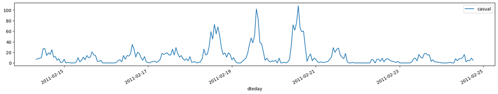

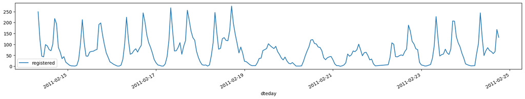

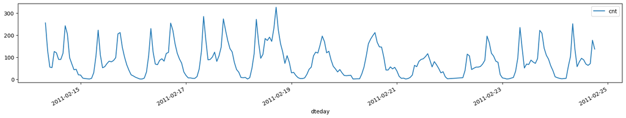

```python
for target_column in target_columns:
    input_df.iloc[1000 : 1000 + 24 * 10].plot(
        x=timestamp_column, y=target_column, figsize=(20, 3)
    )
```

## Fine-tuning the model

### Configure columns and preprocessor for fine-tuning

We define the control columns or features whose values will be known into the future, and set up the time series preprocessor.

```python
SEED = 42
set_seed(SEED)

control_columns = [
    "season",
    "yr",
    "mnth",
    "holiday",
    "weekday",
    "workingday",
    "weathersit",
    "temp",
    "atemp",
    "hum",
    "windspeed",
]

tsp = TimeSeriesPreprocessor(
    timestamp_column=timestamp_column,
    target_columns=target_columns,
    control_columns=control_columns,
    context_length=context_length,
    prediction_length=prediction_length,
    scaling=True,
    encode_categorical=False,
)
```

### Load the model for fine-tuning

```python
finetune_forecast_model = TinyTimeMixerForPrediction.from_pretrained(
    "ibm-granite/granite-timeseries-ttm-r2",
    revision=TTM_MODEL_REVISION,
    num_input_channels=tsp.num_input_channels,
    decoder_mode="mix_channel",  # exog:  set to mix_channel for mixing channels in history
    prediction_channel_indices=tsp.prediction_channel_indices,
    exogenous_channel_indices=tsp.exogenous_channel_indices,
    fcm_context_length=1,  # exog: indicates lag length to use in the exog fusion. for Ex. if today sales can get affected by discount on +/- 2 days, mention 2
    fcm_use_mixer=True,  # exog: Try true (1st option) or false
    fcm_mix_layers=2,  # exog: Number of layers for exog mixing
    enable_forecast_channel_mixing=True,  # exog: set true for exog mixing
    fcm_prepend_past=True,  # exog: set true to include lag from history during exog infusion.
)
```

```
Some weights of TinyTimeMixerForPrediction were not initialized from the model checkpoint at ibm-granite/granite-timeseries-ttm-r2 and are newly initialized: ['decoder.decoder_block.mixers.0.channel_feature_mixer.gating_block.attn_layer.bias', 'decoder.decoder_block.mixers.0.channel_feature_mixer.ga…
You should probably TRAIN this model on a down-stream task to be able to use it for predictions and inference.
```

### Freeze the TTM Backbone

During fine-tuning we freeze the backbone and focus on tuning only the parameters in the decoder. This reduces the overall number of parameters being tuned and maintains what the encoder learned during pretraining.

```python
print(
    "Number of params before freezing backbone",
    count_parameters(finetune_forecast_model),
)

# Freeze the backbone of the model
for param in finetune_forecast_model.backbone.parameters():
    param.requires_grad = False

# Count params
print(
    "Number of params after freezing the backbone",
    count_parameters(finetune_forecast_model),
)
```

```
Number of params before freezing backbone 867631
Number of params after freezing the backbone 314693
```

### Get the datasets for fine tuning

We use the `get_datasets` function in conjunction with the time series preprocessor. We split the data into training, validation, and test sets. The training set is used to train the model, while the test set is used to evaluate its performance. Note that we inspect the `resolution_prefix_tuning` attribute of the model config to enable the frequency token if needed.

```python
split_config = {"train": 0.5, "test": 0.25}
train_df, valid_df, test_df = prepare_data_splits(
    input_df, context_length=context_length, split_config=split_config
)

train_dataset, valid_dataset, test_dataset = get_datasets(
    tsp,
    input_df,
    split_config,
    use_frequency_token=finetune_forecast_model.config.resolution_prefix_tuning,
)
print(
    f"Data lengths: train = {len(train_dataset)}, val = {len(valid_dataset)}, test = {len(test_dataset)}"
)
```

```
Data lengths: train = 8082, val = 4251, test = 4249
```

### Set up a Trainer for Fine-tuning

Configure a Trainer for use in fine-tuning and evaluating the model.

```python
# Important parameters
learning_rate = 0.000298  # 0.000298364724028334
num_epochs = 50  # Ideally, we need more epochs (try offline preferably in a gpu for faster computation)
batch_size = 64

print(f"Using learning rate = {learning_rate}")
finetune_forecast_args = TrainingArguments(
    output_dir=os.path.join(OUT_DIR, "output"),
    overwrite_output_dir=True,
    learning_rate=learning_rate,
    num_train_epochs=num_epochs,
    do_eval=True,
    eval_strategy="epoch",
    per_device_train_batch_size=batch_size,
    per_device_eval_batch_size=batch_size,
    dataloader_num_workers=4,
    report_to=None,
    save_strategy="epoch",
    logging_strategy="epoch",
    save_total_limit=1,
    logging_dir=os.path.join(
        OUT_DIR, "logs"
    ),  # Make sure to specify a logging directory
    load_best_model_at_end=True,  # Load the best model when training ends
    metric_for_best_model="eval_loss",  # Metric to monitor for early stopping
    greater_is_better=False,  # For loss
    use_cpu=device != "cuda",  # Remove when GPU is available
)

# Create the early stopping callback
early_stopping_callback = EarlyStoppingCallback(
    early_stopping_patience=10,  # Number of epochs with no improvement after which to stop
    early_stopping_threshold=0.0,  # Minimum improvement required to consider as improvement
)
tracking_callback = TrackingCallback()

# Optimizer and scheduler
optimizer = AdamW(finetune_forecast_model.parameters(), lr=learning_rate)
scheduler = OneCycleLR(
    optimizer,
    learning_rate,
    epochs=num_epochs,
    steps_per_epoch=math.ceil(len(train_dataset) / (batch_size)),
)

finetune_forecast_trainer = Trainer(
    model=finetune_forecast_model,
    args=finetune_forecast_args,
    train_dataset=train_dataset,
    eval_dataset=valid_dataset,
    callbacks=[early_stopping_callback, tracking_callback],
    optimizers=(optimizer, scheduler),
)
```

```
Using learning rate = 0.000298
```

### Train the Model

Here we train the model on the training data. This tunes only the weights in the decoder and output layers, as the other weights have been frozen, taking into account the interactions between all the channels.

```python
# Fine tune
finetune_forecast_trainer.train()
```

[2159/6350 39:02 < 1:15:51, 0.92 it/s, Epoch 17/50]

| Epoch | Training Loss | Validation Loss |
| --- | --- | --- |
| 1 | 0.959600 | 1.083845 |
| 2 | 0.700600 | 0.883336 |
| 3 | 0.593600 | 0.837278 |
| 4 | 0.534000 | 0.781663 |
| 5 | 0.485400 | 0.715320 |
| 6 | 0.430700 | 0.663338 |
| 7 | 0.384300 | 0.655128 |
| 8 | 0.347100 | 0.666907 |
| 9 | 0.319300 | 0.659244 |
| 10 | 0.296100 | 0.671924 |
| 11 | 0.278200 | 0.689273 |
| 12 | 0.263000 | 0.704855 |
| 13 | 0.250500 | 0.709707 |
| 14 | 0.238800 | 0.720721 |
| 15 | 0.230300 | 0.727515 |
| 16 | 0.220500 | 0.730675 |
| 17 | 0.214100 | 0.664024 |

```
[TrackingCallback] Mean Epoch Time = 94.38814809743096 seconds, Total Train Time = 2353.4884119033813
```

```
TrainOutput(global_step=2159, training_loss=0.3968302058422659, metrics={'train_runtime': 2353.4893, 'train_samples_per_second': 171.703, 'train_steps_per_second': 2.698, 'total_flos': 5123085497413632.0, 'train_loss': 0.3968302058422659, 'epoch': 17.0})
```

### Evaluate the Model

Evaluate the fine-tuned model on the test dataset.

```python
# Define some standard metrics.


def custom_metric(actual, prediction, column_header="results"):
    """Simple function to compute MSE"""
    a = np.asarray(actual.tolist())
    p = np.asarray(prediction.tolist())

    mask = ~np.any(np.isnan(a), axis=1)

    mse = np.mean(np.square(a[mask, :] - p[mask, :]))
    mae = np.mean(np.abs(a[mask, :] - p[mask, :]))
    return pd.DataFrame(
        {
            column_header: {
                "mean_squared_error": mse,
                "root_mean_squared_error": np.sqrt(mse),
                "mean_absolute_error": mae,
            }
        }
    )
```

```python
# generate forecasts using the finetuned model
pipeline = TimeSeriesForecastingPipeline(
    finetune_forecast_model,
    device=device,  # Specify your local GPU or CPU.
    feature_extractor=tsp,
    batch_size=batch_size,
)

# Make a forecast on the target column given the input data.
finetune_forecast = pipeline(test_df)
finetune_forecast.head()
```

```
Device set to use cpu
```

|  | dteday | casual_prediction | registered_prediction | cnt_prediction | casual | registered | cnt |
| --- | --- | --- | --- | --- | --- | --- | --- |
| 0 | 2012-07-02 07:00:00 | [22.253469124569726, 38.99582086421544, 55.153... | [436.397161251816, 290.8293021366277, 194.8625... | [477.0425252437017, 344.1286143467806, 266.199... | [19.999999784280565, 56.00000112850756, 70.000... | [548.0000003818889, 239.0000059497106, 103.999... | [567.9999950828335, 294.99999472956125, 173.99... |
| 1 | 2012-07-02 08:00:00 | [27.97735021929407, 51.55401211093594, 65.6164... | [406.19662624458755, 248.8994513400366, 233.08... | [402.89918949616737, 302.08535545771355, 317.8... | [56.00000112850756, 70.00000068788127, 66.9999... | [239.0000059497106, 103.99999997895328, 133.99... | [294.99999472956125, 173.9999995756801, 200.99... |
| 2 | 2012-07-02 09:00:00 | [62.89392800922404, 76.33281425661728, 84.0711... | [180.32882384573583, 172.852180382278, 214.666... | [245.2982436394882, 277.84996115866727, 342.85... | [70.00000068788127, 66.99999913079048, 74.0000... | [103.99999997895328, 133.9999992249458, 183.00... | [173.9999995756801, 200.99999869175633, 257.00... |
| 3 | 2012-07-02 10:00:00 | [78.06842648804273, 84.98778663354709, 84.1014... | [153.40651459506947, 197.20135244948924, 212.4... | [255.63717864597976, 326.50304968279244, 344.5... | [66.99999913079048, 74.00000122259232, 74.0000... | [133.9999992249458, 183.0000023631694, 161.999... | [200.99999869175633, 257.00000039775625, 235.9... |
| 4 | 2012-07-02 11:00:00 | [79.00650240224942, 82.25737305897802, 78.3291... | [201.85388959019735, 201.06888798239177, 192.5... | [313.4135773422054, 323.1916446311328, 300.962... | [74.00000122259232, 74.00000122259232, 79.0000... | [183.0000023631694, 161.99999938973104, 151.00... | [257.00000039775625, 235.99999975800628, 229.9... |

```python
custom_metric(
    finetune_forecast["cnt"], finetune_forecast["cnt_prediction"], "fine-tune forecast"
)
```

|  | fine-tune forecast |
| --- | --- |
| mean_squared_error | 13982.258960 |
| root_mean_squared_error | 118.246602 |
| mean_absolute_error | 84.209948 |

### Plot the Predictions vs. Actuals

Plot the predictions vs. actuals for some random samples of time intervals in test dataset.

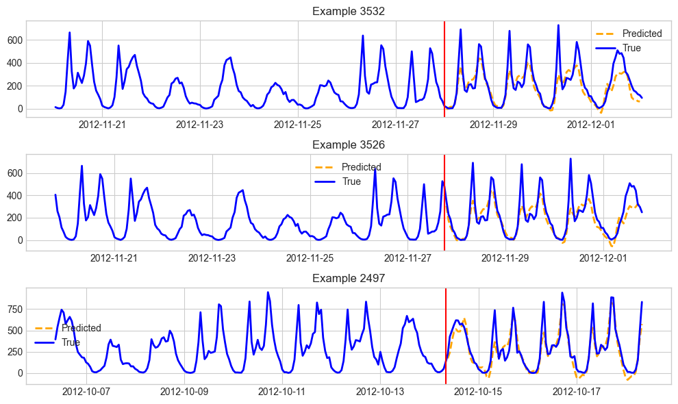

```python
# plot
plot_predictions(
    input_df=test_df,
    predictions_df=finetune_forecast,
    freq="h",
    timestamp_column=timestamp_column,
    channel=target_columns[2],
    indices=[3532, 3526, 2497],
)
```

## Prepare for Deployment

In order to prepare for deployment on [watsonx.ai](https://www.ibm.com/docs/en/software-hub/5.4.x?topic=setup-deploying-custom-foundation-models), we need to save the model weights and configuration files, as well as preprocessor configuration, and [time series runtime](https://github.com/ibm-granite/granite-tsfm/tree/main/services/inference) configuration.

All the needed content will be saved to the folder specified by `deployment_folder`.

```python
deployment_folder = "./ttm_deployment"
save_deployment_package(deployment_folder, finetune_forecast_model, ts_processor=tsp)
```

```
INFO:p-20627:t-8532172992:processor.py:save_pretrained:Feature extractor saved in ttm_deployment/preprocessor_config.json
INFO:p-20627:t-8532172992:tsfm_config.py:save_pretrained:Configuration saved in ttm_deployment/tsfm_config.json
```

## Links

- Library: [Granite TSFM on Github](https://github.com/ibm-granite/granite-tsfm)
- Model: [TinyTimeMixer on HuggingFace](https://huggingface.co/ibm-granite/granite-timeseries-ttm-v1)
- Dataset: [Bike Sharing Dataset on Kaggle](https://www.kaggle.com/datasets/lakshmi25npathi/bike-sharing-dataset)
- IBM Cloud support: pretrained and finetuned model inference on [watsonx.ai](https://www.ibm.com/products/watsonx-ai)

### Author

**Wesley Gifford**, Senior Technical Staff Member at IBM

Copyright © 2025-2026 IBM. This notebook and its source code are released under the terms of the Apache 2.0 License.